# Case 31: Summary of Data Analysis for R3, R6, and R4

Employees Federal Credit Union

Author

Carmen Lia Jimenez

## 1 Introduction

This report addresses three research questions from Case 31: Employees Federal Credit Union (EFCU).

- **R3:** Members’ attitudes toward employee proficiency.
- **R6:** Members’ perceptions of operational effectiveness.
- **R4:** Differences in employee proficiency, service awareness, and operational effectiveness based on residence.

The analysis prioritizes descriptive statistics, including means, frequencies, and percentages, before conducting inferential statistical tests.

Reliability and factor analyses were completed in a previous assignment and are not repeated here.

## 2 Data Preparation

```r
library(haven)
library(knitr)

possible_files <- c(
  "Case 31 Data_efcu_4 (1).sav",
  "Case 31 Data_efcu_4.sav"
)

found <- possible_files[file.exists(possible_files)]

if (length(found) == 0) {
  stop("Place the SAV dataset in the same folder as the QMD.")
}

efcu <- read_sav(found[1])

names(efcu) <- tolower(names(efcu))

get_num <- function(v) {
  as.numeric(haven::zap_missing(efcu[[v]]))
}

get_scale <- function(v, allowed) {
  x <- get_num(v)
  x[!(x %in% allowed)] <- NA_real_
  x
}

fmt_p <- function(p) {
  ifelse(
    is.na(p), "NA",
    ifelse(p < .001, "< .001", sprintf("= %.3f", p))
  )
}

show_table <- function(x) {
  knitr::kable(x, row.names = FALSE)
}

residence <- factor(
  get_scale("q38", c(1, 2)),
  levels = c(1, 2),
  labels = c("Near headquarters", "Elsewhere")
)

cat("Observations:", nrow(efcu), "\n")
```

```
Observations: 128
```

```r
cat("Variables:", ncol(efcu), "\n")
```

```
Variables: 53
```

```r
show_table(data.frame(
  Residence = levels(residence),
  N = as.integer(table(residence)),
  Percent = round(
    100 * as.integer(table(residence)) /
      sum(!is.na(residence)), 1
  )
))
```

Table 1: Respondents by residence

| Residence | N | Percent |
| --- | --- | --- |
| Near headquarters | 57 | 44.5 |
| Elsewhere | 71 | 55.5 |

The dataset contains 128 respondents. Of these, 57 live near headquarters and 71 live elsewhere.

## 3 R3: Employee Proficiency

### 3.1 Descriptive Statistics

**Research Question:** What are members’ attitudes and beliefs about the proficiency of credit union employees?

Employee proficiency is measured by Q3 through Q6, including courtesy, helpfulness, professionalism, and availability.

```r
r3_vars <- paste0("q", 3:6)

r3_labels <- c(
  "Courtesy",
  "Helpfulness",
  "Professionalism",
  "Availability"
)

r3_items <- as.data.frame(
  lapply(r3_vars, get_scale, allowed = 1:5)
)

names(r3_items) <- r3_vars

r3_desc <- data.frame(
  Item = r3_labels,
  N = sapply(r3_items, function(x) sum(!is.na(x))),
  Mean = round(sapply(r3_items, mean, na.rm = TRUE), 2),
  SD = round(sapply(r3_items, sd, na.rm = TRUE), 2)
)

show_table(r3_desc)
```

Table 2: Employee proficiency ratings

| Item | N | Mean | SD |
| --- | --- | --- | --- |
| Courtesy | 128 | 4.35 | 0.66 |
| Helpfulness | 128 | 4.31 | 0.70 |
| Professionalism | 128 | 4.08 | 0.66 |
| Availability | 128 | 4.08 | 0.79 |

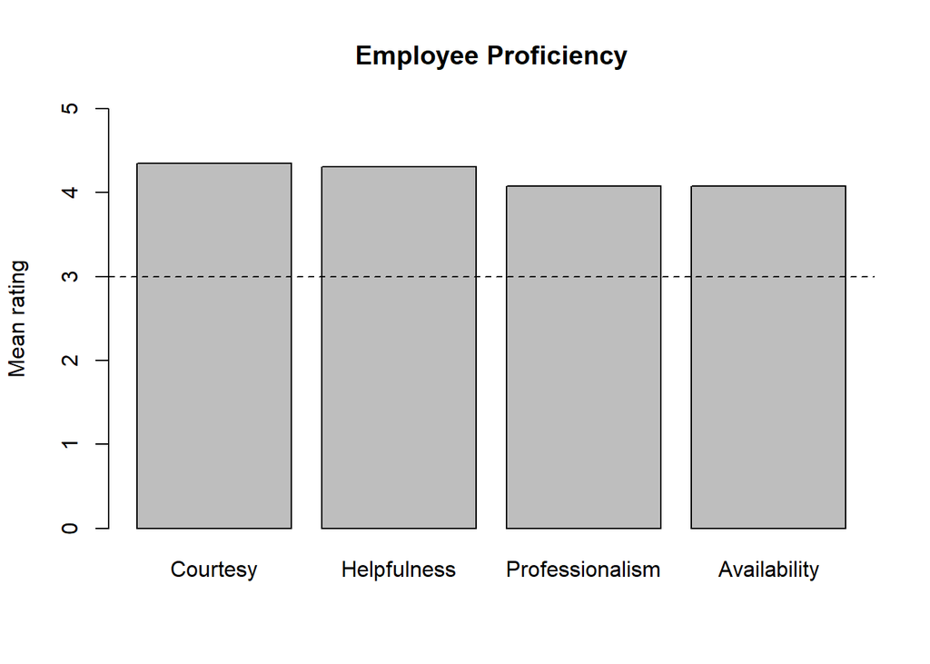

Figure 1: Mean employee proficiency ratings

```r
barplot(
  r3_desc$Mean,
  names.arg = r3_labels,
  ylim = c(0, 5),
  ylab = "Mean rating",
  main = "Employee Proficiency"
)

abline(h = 3, lty = 2)
```

```r
r3_index <- rowMeans(
  r3_items,
  na.rm = FALSE
)

r3_valid <- na.omit(r3_index)

show_table(data.frame(
  N = length(r3_valid),
  Mean = round(mean(r3_valid), 3),
  SD = round(sd(r3_valid), 3)
))
```

Table 3: Employee Proficiency Index

| N | Mean | SD |
| --- | --- | --- |
| 128 | 4.205 | 0.594 |

### 3.2 One-Sample T-Test

A one-sample t-test evaluates whether employee proficiency ratings differ from the neutral midpoint of 3.

```r
r3_test <- t.test(r3_valid, mu = 3)

show_table(data.frame(
  Mean = round(mean(r3_valid), 3),
  T = round(unname(r3_test$statistic), 3),
  DF = round(unname(r3_test$parameter), 2),
  P = fmt_p(r3_test$p.value),
  CI_Lower = round(r3_test$conf.int[1], 3),
  CI_Upper = round(r3_test$conf.int[2], 3)
))
```

Table 4: One-sample t-test for employee proficiency

| Mean | T | DF | P | CI_Lower | CI_Upper |
| --- | --- | --- | --- | --- | --- |
| 4.205 | 22.954 | 127 | < .001 | 4.101 | 4.309 |

### 3.3 R3 Results and Interpretation

Members reported generally favorable perceptions of employee proficiency, with an average index score of **4.21 out of 5** (SD = 0.59).

The highest-rated employee characteristic was **Courtesy**, while **Professionalism** received the lowest average rating.

The overall rating was significantly above the neutral midpoint (*t*(127) = 22.95, *p* < .001).

These findings suggest that employees are generally perceived as courteous, helpful, professional, and available. The relatively lower-rated characteristics may provide opportunities for improvement.

## 4 R6: Operational Effectiveness

### 4.1 Descriptive Statistics

**Research Question:** What are members’ attitudes and beliefs about how effectively the credit union is operated?

Operational effectiveness is examined using Q9–Q12, Q31–Q34, and Q37. The variables are evaluated separately because they represent different operational dimensions and measurement scales.

```r
r6_vars <- c(
  "q10_r", "q31", "q32",
  "q33", "q34", "q37_r"
)

r6_midpoints <- c(2.5, 3, 3, 3, 3, 3)

r6_desc <- do.call(rbind, lapply(
  seq_along(r6_vars),
  function(i) {

    v <- r6_vars[i]

    allowed <- if (v == "q10_r") 1:4 else 1:5
    x <- get_scale(v, allowed)

    data.frame(
      Variable = toupper(v),
      N = sum(!is.na(x)),
      Mean = round(mean(x, na.rm = TRUE), 3),
      SD = round(sd(x, na.rm = TRUE), 3),
      Midpoint = r6_midpoints[i]
    )
  }
))

show_table(r6_desc)
```

Table 5: Operational effectiveness rating statistics

| Variable | N | Mean | SD | Midpoint |
| --- | --- | --- | --- | --- |
| Q10_R | 128 | 3.469 | 0.639 | 2.5 |
| Q31 | 128 | 3.945 | 0.679 | 3.0 |
| Q32 | 128 | 3.719 | 0.793 | 3.0 |
| Q33 | 128 | 3.594 | 0.681 | 3.0 |
| Q34 | 128 | 3.461 | 0.783 | 3.0 |
| Q37_R | 121 | 4.066 | 0.727 | 3.0 |

### 4.2 Frequency Distributions

Categorical and ordinal operational items are summarized using frequencies and percentages.

```r
r6_cat_vars <- c("q9_r", "q11", "q12")

r6_freq <- do.call(rbind, lapply(
  r6_cat_vars,
  function(v) {

    x <- get_num(v)
    tab <- table(x)

    data.frame(
      Variable = toupper(v),
      Response = names(tab),
      Frequency = as.integer(tab),
      Percentage = round(
        100 * as.integer(tab) / sum(tab), 1
      )
    )
  }
))

show_table(r6_freq)
```

Table 6: Operational effectiveness response distributions

| Variable | Response | Frequency | Percentage |
| --- | --- | --- | --- |
| Q9_R | 2 | 29 | 22.7 |
| Q9_R | 3 | 99 | 77.3 |
| Q11 | 1 | 125 | 97.7 |
| Q11 | 2 | 3 | 2.3 |
| Q12 | 1 | 74 | 57.8 |
| Q12 | 2 | 32 | 25.0 |
| Q12 | 3 | 22 | 17.2 |

### 4.3 One-Sample T-Tests

The appropriate rating items are compared with their respective scale midpoints. Q10r has a four-point scale, while the other ratings use five-point scales.

```r
r6_tests <- do.call(rbind, lapply(
  seq_along(r6_vars),
  function(i) {

    v <- r6_vars[i]
    midpoint <- r6_midpoints[i]

    allowed <- if (v == "q10_r") 1:4 else 1:5
    x <- na.omit(get_scale(v, allowed))

    test <- t.test(x, mu = midpoint)

    data.frame(
      Variable = toupper(v),
      Mean = round(mean(x), 3),
      T = round(unname(test$statistic), 3),
      DF = round(unname(test$parameter), 2),
      P = test$p.value
    )
  }
))

r6_tests$P_Adjusted <- p.adjust(
  r6_tests$P,
  method = "holm"
)

r6_display <- r6_tests

r6_display$P <- fmt_p(r6_display$P)
r6_display$P_Adjusted <- fmt_p(r6_display$P_Adjusted)

show_table(r6_display)
```

Table 7: One-sample t-tests for operational ratings

| Variable | Mean | T | DF | P | P_Adjusted |
| --- | --- | --- | --- | --- | --- |
| Q10_R | 3.469 | 17.149 | 127 | < .001 | < .001 |
| Q31 | 3.945 | 15.742 | 127 | < .001 | < .001 |
| Q32 | 3.719 | 10.254 | 127 | < .001 | < .001 |
| Q33 | 3.594 | 9.866 | 127 | < .001 | < .001 |
| Q34 | 3.461 | 6.663 | 127 | < .001 | < .001 |
| Q37_R | 4.066 | 16.125 | 120 | < .001 | < .001 |

### 4.4 R6 Results and Interpretation

The findings reveal variation across different dimensions of operational effectiveness.

Among Q31–Q34, **Q31 received the highest mean rating** (3.95), while **Q34 received the lowest** (3.46).

Across the six numerical rating items, 6 showed statistically significant differences from their respective scale midpoints after adjustment.

The distribution of Q9r, Q11, and Q12 responses provides additional insight into operational processes and members’ experiences.

Overall, operational effectiveness is best understood through these individual dimensions rather than one combined score. Lower-rated aspects warrant further investigation.

## 5 R4a: Employee Proficiency by Residence

### 5.1 Group Descriptive Statistics

**Research Question:** Do members living near headquarters differ from members living elsewhere in their evaluations of employee proficiency?

```r
r4a_data <- na.omit(data.frame(
  Residence = residence,
  Score = r3_index
))

r4a_groups <- split(
  r4a_data$Score,
  r4a_data$Residence
)

r4a_desc <- data.frame(
  Residence = names(r4a_groups),
  N = sapply(r4a_groups, length),
  Mean = round(sapply(r4a_groups, mean), 3),
  SD = round(sapply(r4a_groups, sd), 3)
)

show_table(r4a_desc)
```

Table 8: Employee proficiency by residence

| Residence | N | Mean | SD |
| --- | --- | --- | --- |
| Near headquarters | 57 | 4.281 | 0.575 |
| Elsewhere | 71 | 4.144 | 0.606 |

### 5.2 Welch Independent-Samples T-Test

```r
r4a_test <- t.test(
  Score ~ Residence,
  data = r4a_data
)

show_table(data.frame(
  T = round(unname(r4a_test$statistic), 3),
  DF = round(unname(r4a_test$parameter), 2),
  P = fmt_p(r4a_test$p.value),
  CI_Lower = round(r4a_test$conf.int[1], 3),
  CI_Upper = round(r4a_test$conf.int[2], 3)
))
```

Table 9: Welch t-test: Employee proficiency by residence

| T | DF | P | CI_Lower | CI_Upper |
| --- | --- | --- | --- | --- |
| 1.302 | 122.49 | = 0.195 | -0.071 | 0.344 |

### 5.3 R4a Results and Interpretation

Members living near headquarters reported an average employee proficiency score of 4.28, compared with 4.14 among those living elsewhere.

The difference was not statistically significant (Welch *t*(122.49) = 1.3, *p* = 0.195).

These findings suggest that members evaluate employee proficiency similarly regardless of whether they live near headquarters or elsewhere.

## 6 R4b: Service Awareness by Residence

### 6.1 Cross-Tabulations and Association Tests

**Research Question:** Does awareness and use of credit union services differ according to residence?

Q13r through Q26r measure service awareness and use:

- 1 = Unaware
- 2 = Aware but not used
- 3 = Aware and used

```r
service_vars <- paste0("q", 13:26, "_r")

service_names <- c(
  "Regular share accounts",
  "Special subaccounts",
  "Christmas club accounts",
  "Individual retirement accounts",
  "Mastercard credit cards",
  "Signature loans",
  "New car loans",
  "Late model car loans",
  "Older model car loans",
  "Household goods loans",
  "Recreational loans",
  "Share collateralized loans",
  "IRA loans",
  "Line of credit loans"
)

r4b_desc <- do.call(rbind, lapply(
  seq_along(service_vars),
  function(i) {

    x <- get_scale(service_vars[i], 1:3)

    near <- x[residence == "Near headquarters"]
    far <- x[residence == "Elsewhere"]

    data.frame(
      Service = service_names[i],
      Used_Near = round(
        100 * mean(near == 3, na.rm = TRUE), 1
      ),
      Used_Elsewhere = round(
        100 * mean(far == 3, na.rm = TRUE), 1
      ),
      Overall_Used = round(
        100 * mean(x == 3, na.rm = TRUE), 1
      )
    )
  }
))

show_table(r4b_desc)
```

Table 10: Service usage percentages by residence

| Service | Used_Near | Used_Elsewhere | Overall_Used |
| --- | --- | --- | --- |
| Regular share accounts | 12.3 | 8.5 | 10.2 |
| Special subaccounts | 7.0 | 11.3 | 9.4 |
| Christmas club accounts | 8.8 | 8.5 | 8.6 |
| Individual retirement accounts | 24.6 | 21.1 | 22.7 |
| Mastercard credit cards | 43.9 | 43.7 | 43.8 |
| Signature loans | 14.0 | 15.5 | 14.8 |
| New car loans | 17.5 | 19.7 | 18.8 |
| Late model car loans | 10.5 | 11.3 | 10.9 |
| Older model car loans | 7.0 | 11.3 | 9.4 |
| Household goods loans | 8.8 | 8.5 | 8.6 |
| Recreational loans | 8.8 | 11.3 | 10.2 |
| Share collateralized loans | 1.8 | 1.4 | 1.6 |
| IRA loans | 0.0 | 5.6 | 3.1 |
| Line of credit loans | 35.1 | 39.4 | 37.5 |

### 6.2 Chi-Square and Fisher’s Exact Tests

```r
categorical_test <- function(v) {

  x <- get_num(v)
  tab <- table(residence, x)

  if (nrow(tab) < 2 || ncol(tab) < 2) {
    return(data.frame(
      Variable = toupper(v),
      Test = "Insufficient categories",
      P = NA_real_
    ))
  }

  chi <- suppressWarnings(
    chisq.test(tab, correct = FALSE)
  )

  if (any(chi$expected < 5)) {

    result <- fisher.test(
      tab,
      simulate.p.value = TRUE,
      B = 10000
    )

    method <- "Fisher (simulated)"

  } else {

    result <- chi
    method <- "Chi-square"
  }

  data.frame(
    Variable = toupper(v),
    Test = method,
    P = result$p.value
  )
}

set.seed(123)

r4b_tests <- do.call(rbind, lapply(
  service_vars,
  categorical_test
))

r4b_tests$P_Adjusted <- p.adjust(
  r4b_tests$P,
  method = "holm"
)

r4b_display <- r4b_tests

r4b_display$P <- fmt_p(r4b_display$P)
r4b_display$P_Adjusted <- fmt_p(
  r4b_display$P_Adjusted
)

show_table(r4b_display)
```

Table 11: Association between residence and service awareness

| Variable | Test | P | P_Adjusted |
| --- | --- | --- | --- |
| Q13_R | Chi-square | = 0.529 | = 1.000 |
| Q14_R | Chi-square | = 0.666 | = 1.000 |
| Q15_R | Fisher (simulated) | = 0.857 | = 1.000 |
| Q16_R | Chi-square | = 0.849 | = 1.000 |
| Q17_R | Chi-square | = 0.150 | = 1.000 |
| Q18_R | Fisher (simulated) | = 0.316 | = 1.000 |
| Q19_R | Fisher (simulated) | = 0.939 | = 1.000 |
| Q20_R | Chi-square | = 0.269 | = 1.000 |
| Q21_R | Chi-square | = 0.714 | = 1.000 |
| Q22_R | Fisher (simulated) | = 0.626 | = 1.000 |
| Q23_R | Chi-square | = 0.502 | = 1.000 |
| Q24_R | Fisher (simulated) | = 1.000 | = 1.000 |
| Q25_R | Fisher (simulated) | = 0.250 | = 1.000 |
| Q26_R | Chi-square | = 0.613 | = 1.000 |

### 6.3 R4b Results and Interpretation

The most frequently used service was **Mastercard credit cards**, reported as used by 43.8% of respondents.

Service-use percentages varied between the two residence groups.

However, 0 of the 14 association tests remained statistically significant after Holm adjustment.

The findings do not provide statistically reliable evidence that service-awareness patterns differ by residence.

These results describe associations rather than causal relationships.

## 7 R4c: Operational Effectiveness by Residence

### 7.1 Descriptive Statistics and Welch T-Tests

**Research Question:** Do operational effectiveness perceptions differ by residence?

```r
r4c_vars <- c(
  "q10_r", "q31", "q32",
  "q33", "q34", "q37_r"
)

r4c_numeric <- do.call(rbind, lapply(
  r4c_vars,
  function(v) {

    allowed <- if (v == "q10_r") 1:4 else 1:5

    x <- get_scale(v, allowed)

    dat <- na.omit(data.frame(
      Residence = residence,
      Score = x
    ))

    near <- dat$Score[
      dat$Residence == "Near headquarters"
    ]

    far <- dat$Score[
      dat$Residence == "Elsewhere"
    ]

    test <- t.test(
      Score ~ Residence,
      data = dat
    )

    data.frame(
      Variable = toupper(v),
      Mean_Near = round(mean(near), 3),
      Mean_Elsewhere = round(mean(far), 3),
      T = round(unname(test$statistic), 3),
      DF = round(unname(test$parameter), 2),
      P = test$p.value
    )
  }
))

r4c_numeric$P_Adjusted <- p.adjust(
  r4c_numeric$P,
  method = "holm"
)

r4c_display <- r4c_numeric

r4c_display$P <- fmt_p(r4c_display$P)
r4c_display$P_Adjusted <- fmt_p(
  r4c_display$P_Adjusted
)

show_table(r4c_display)
```

Table 12: Operational ratings and Welch t-tests by residence

| Variable | Mean_Near | Mean_Elsewhere | T | DF | P | P_Adjusted |
| --- | --- | --- | --- | --- | --- | --- |
| Q10_R | 3.491 | 3.451 | 0.353 | 117.53 | = 0.724 | = 1.000 |
| Q31 | 4.053 | 3.859 | 1.616 | 121.26 | = 0.109 | = 0.544 |
| Q32 | 3.684 | 3.746 | -0.439 | 118.94 | = 0.661 | = 1.000 |
| Q33 | 3.596 | 3.592 | 0.040 | 112.93 | = 0.968 | = 1.000 |
| Q34 | 3.281 | 3.606 | -2.280 | 94.24 | = 0.025 | = 0.149 |
| Q37_R | 4.019 | 4.104 | -0.657 | 118.74 | = 0.513 | = 1.000 |

### 7.2 Categorical Operational Measures

```r
set.seed(456)

r4c_cat_vars <- c("q9_r", "q11", "q12")

r4c_cat <- do.call(rbind, lapply(
  r4c_cat_vars,
  categorical_test
))

r4c_cat$P_Adjusted <- p.adjust(
  r4c_cat$P,
  method = "holm"
)

r4c_cat_display <- r4c_cat

r4c_cat_display$P <- fmt_p(
  r4c_cat_display$P
)

r4c_cat_display$P_Adjusted <- fmt_p(
  r4c_cat_display$P_Adjusted
)

show_table(r4c_cat_display)
```

Table 13: Categorical operational measures by residence

| Variable | Test | P | P_Adjusted |
| --- | --- | --- | --- |
| Q9_R | Chi-square | = 0.698 | = 1.000 |
| Q11 | Fisher (simulated) | = 0.585 | = 1.000 |
| Q12 | Chi-square | = 0.275 | = 0.825 |

### 7.3 R4c Results and Interpretation

The numerical operational effectiveness comparisons showed 0 statistically significant differences after Holm adjustment.

The categorical operational measures showed 0 statistically significant associations after adjustment.

The lowest unadjusted p-value among the numerical measures was observed for **Q34**.

Overall, the results do not establish robust residence-related differences in the selected operational effectiveness measures.

The findings should be interpreted cautiously because statistical associations do not establish causation.

## 8 Overall Findings and Implications

This analysis addressed R3, R6, and the three components of R4.

**R3:** Members generally provided favorable employee proficiency evaluations, with an average composite score of 4.21.

**R6:** Operational effectiveness varied across different aspects of credit union services. Q31 received a relatively high average rating, while Q34 was comparatively lower.

**R4a:** Differences in employee proficiency perceptions by residence were not statistically significant.

**R4b:** 0 service-awareness comparisons remained significant after adjustment.

**R4c:** 0 numerical and 0 categorical comparisons remained significant after adjustment.

Overall, the credit union can build on generally favorable employee evaluations while investigating lower-rated operational characteristics and potential opportunities for continuous improvement.

## 9 Appendix: GitHub Links

- **GitHub Repository:** [View GitHub Repository](https://github.com/carmenjimenez97/case31-reliability-factor-analysis)
- **GitHub Pages:** [View Published HTML Report](https://carmenjimenez97.github.io/case31-reliability-factor-analysis/IC_Case31_R3_R6_R4.html)